# Air Pollution, Seasonality, and Respiratory ER Visits in Virginia

### Sana Rehan, Kian Thomasbeer, Ariyah Walker

# Background & Question

Particulate matter is airborne pollution small enough to enter the respiratory tract. PM2.5 refers to particles ≤ 2.5 micrometers, while PM10 refers to particles ≤ 10 micrometers. This project examines whether changes in PM2.5 and PM10 help predict respiratory-related emergency department visits across Virginia, and whether this relationship changes by season and socioeconomic conditions.

How do PM2.5 and PM10 relate to respiratory-related ER visits across Virginia?

How do seasonal trends and socioeconomic factors moderate this relationship?

**Motivation:**  
Respiratory illness can place major pressure on hospitals, especially during seasonal surges. If air pollution helps predict increases in ER visits, public health officials, hospitals, and Virginia residents could better prepare for high-risk periods.

# Data

We combined data from three public government sources. Respiratory ER visit counts came from the Virginia Department of Health. PM2.5 and PM10 air quality data came from the EPA. Socioeconomic variables, including median household income, employment, and wages, came from HDPulse and the Bureau of Labor Statistics.

The main challenge was aligning datasets with different time and geographic scales. EPA pollution data were daily, while VDH emergency room data were weekly, so daily pollutant measurements were aggregated into weekly averages. Air quality monitor locations were also mapped to Virginia health districts, and socioeconomic variables were merged by health district and year.

#Literature

Previous studies found that short-term increases in particulate matter are associated with higher respiratory ER visits. Weichenthal et al. found stronger associations using a three-day PM2.5 average, while Peel et al. found that pollution effects differ by illness and lag period. Our project builds on this by examining whether the pollution effect changes by season in Virginia.

# Methods

We first used multiple linear regression to model ER visit counts using air quality, seasonality, and socioeconomic predictors. The residual plots showed strong non-constant variance, so we tried a log(y + 1) transformation. Because ER visits are count data and the Poisson model showed overdispersion, we ultimately used a Negative Binomial regression model.

Final model: **Negative Binomial**

**Why:**  
The Negative Binomial model fit the data much better than the Poisson model. The Poisson model had an AIC of 372,927.14, while the Negative Binomial model had an AIC of 61,538.84. This confirmed that the Negative Binomial model was more appropriate for overdispersed ER visit counts.

# Key Result

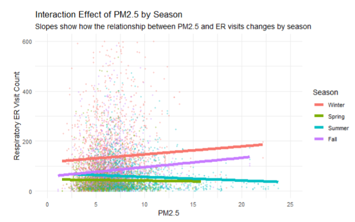

**Figure 1:**

# Seasonal Patterns

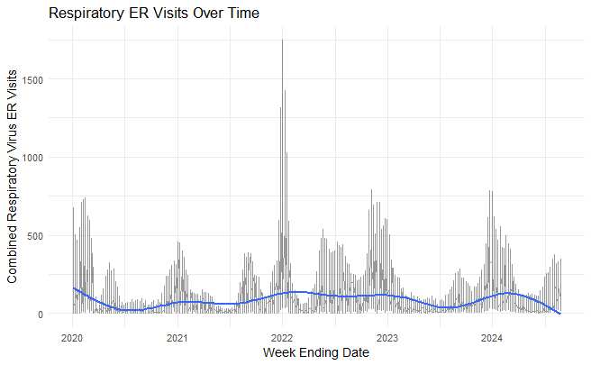

**Figure 2:**

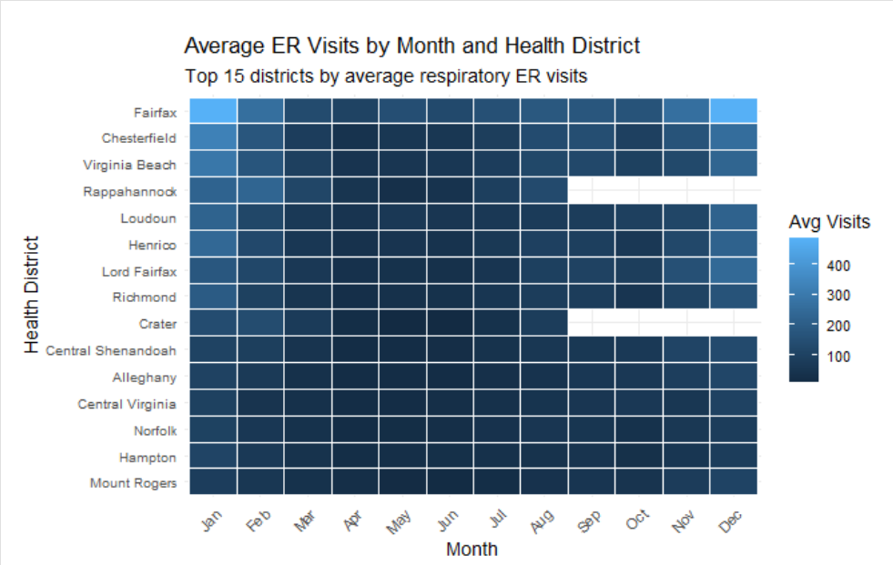

**Figure 3:**

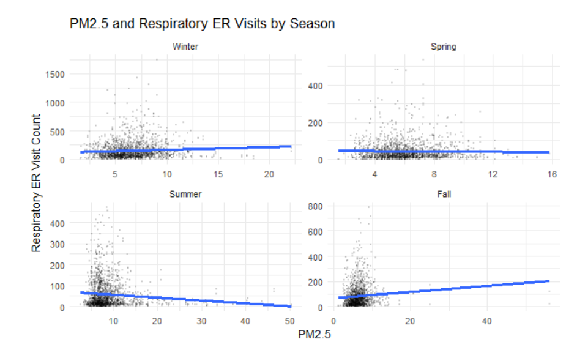

**Figure 4:**

Respiratory ER visits follow a strong seasonal pattern, with clear peaks in winter and lower levels in spring and early summer across districts. PM2.5 levels are relatively stable throughout the year, so the seasonal rise in ER visits is not driven by pollution alone. Instead, the relationship between PM2.5 and ER visits becomes stronger during the fall and winter, suggesting that seasonal factors like viral activity increase sensitivity to pollution.

# Model Justification

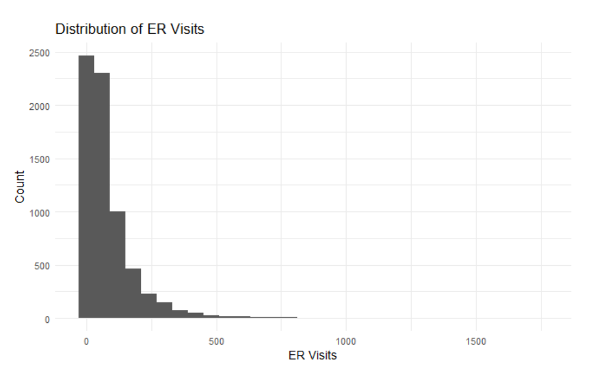

**Figure 5:**

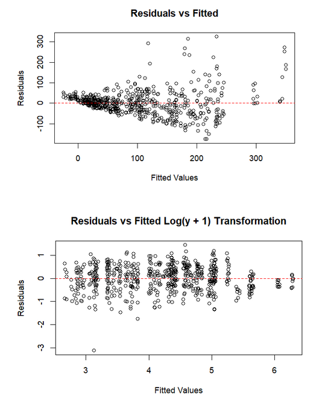

**Figure 6:**

The residual plots show that the original linear model violates constant variance. The log transformation improves the pattern, but the data still support using a Negative Binomial model.

# Findings

The visualizations showed clear winter peaks in ER visits and lower levels during spring and summer. PM2.5 levels were more stable across the year, suggesting that pollution alone does not explain ER visits. Instead, the effect of PM2.5 appears to depend on seasonal conditions, especially during the fall transition into respiratory illness season.

Respiratory ER visits were driven by a combination of seasonality, socioeconomic factors, and air quality. PM2.5 had a positive baseline relationship with ER visits, but the strength of this relationship depended heavily on the time of year. September and October showed especially strong positive interaction effects, while summer months showed weaker effects.

Median household income, wages, and January employment were important predictors of ER visits. These variables likely act as proxies for population density, healthcare access, and broader regional differences. This suggests that respiratory ER visits are not only an environmental issue, but also a socioeconomic one.

# Implications

Public health responses should not use the same air quality threshold year-round. Instead, alerts and hospital planning should be seasonally targeted, especially during fall and winter. Hospitals and health departments could use these patterns to prepare for predictable increases in respiratory ER demand.

# Capstone Experience

This project required working through messy real-world data, including mismatched time scales, missing PM10 data, and geographic mapping challenges. A major pivot was moving from linear regression to Poisson and then to Negative Binomial regression after checking model assumptions. The project shows how statistical modeling must adapt when real data violate ideal conditions.

# References

Peel et al. (2005), Ambient Air Pollution and Respiratory Emergency Department Visits

Weichenthal et al. (2016), Fine Particulate Matter and Emergency Room Visits for Respiratory Illness

[output not shown]